# Expressivness in Association to Attachment Style

Claudia Bobadilla

August 9, 2023

```r
library(haven)
```

```r
#Load the data
labdata<-read_sav("SummerStatsFinalProject/data_ier 2.sav")
```

## Predictions

### Negative Expressivity

Attachment avoidance will be negatively associated with negative experessivity and attachtment anxiety will be negatively associated with negative experessivity.

### Positive Expressivity

Attachment avoidance will be negatively associated with positive expressivity and attachment anxiety will be positively associated with positive expressivity.

```r
#Negative Expressivity
  #(a) The higher someone scores on attachment avoidance, the less they would be willing to express their emotions within a negative event/context
  #(b)) The higher someone scores on attachment anxiety, the less they would be willing to express their emotions within a negative event/context

#Positive Expressivity
  #(a) The higher someone scores on attachment avoidance, the less they would be willing to express their emotions within a positive event/context
  #(b) The higher someone scores on attachment anxiety, the more they would be willing to express their emotions within a positive event/context
```

```r
#Process
#Condense vignette 1 & 2 (positive,target's willingness to express emotion to partner)
#condense vignette 3 & 4 (negative,target's willingness to express emotion to partner)

labdata$positive_exp<-rowMeans(labdata[,c(10,20)])
labdata$negative_exp<-rowMeans(labdata[,c(30,40)])

#"labdata$positive_exp", refers to adding a new titled column into my dataset

#"<-rowMeans(labdata[,c(10,20)])", refers to combining both scores on the positive vignettes, as each Target participant was assessed twice

#Same goes for the negative vignettes

#Here is how to check if added these new variables or 'condensed' columns

  #colnames(labdata)
```

## Descriptives

### Descriptive Statistics for Expressivity

```r
#Target Measure Only

#There were 4 vignettes, 2 negative and 2 positives
#Each one had a range of 8 mixed emotions to rate the intensity of for each vignette; each vignette being a set of different mixed emotions the target was provided with

#The target was then asked how willingly they were to express such rated emotions in this given context to their partner

#Target's instructions: "Imagine that you called your partner and started talking about your day. Below are short sections from your talk. Please rate the intensity of the emotions you might have experienced during the times you are talking."


#Here: Target's willingness to express emotions


c(summary(labdata$negative_exp),"SD"=sd(labdata$negative_exp,na.rm=T))
```

```
##       Min.    1st Qu.     Median       Mean    3rd Qu.       Max.       NA's
##  1.0000000  1.6875000  2.2500000  2.2722701  2.8125000  4.4375000 10.0000000
##         SD
##  0.7202794
```

```r
c(summary(labdata$positive_exp),"SD"=sd(labdata$positive_exp,na.rm=T))
```

```
##       Min.    1st Qu.     Median       Mean    3rd Qu.       Max.       NA's
##  1.9375000  2.9687500  3.3125000  3.3024425  3.6250000  5.0000000 10.0000000
##         SD
##  0.6211271
```

```r
#Key reminder: "na.rm=T" removes any NA values if any, scan data prior
```

### Descriptive Statistics for Attachment Styles

```r
#Scale used: Revised Adult Attachment Scale

  #Two separate subscales in this questionnaire each assess avoidant and anxious            attachment style

      #Each participant can have different scores for each category such as: Low and high,        high and low, high and high, or low and low variations

c(summary(labdata$Target_Attachment_Avoidance),"SD"=sd(labdata$Target_Attachment_Avoidance,na.rm=T))
```

```
##      Min.   1st Qu.    Median      Mean   3rd Qu.      Max.      NA's        SD
## 1.6666667 2.0000000 2.5000000 2.5877660 2.9166667 4.3333333 3.0000000 0.6473878
```

```r
c(summary(labdata$Target_Attachment_Anxiety),"SD"=sd(labdata$Target_Attachment_Anxiety,na.rm=T))
```

```
##      Min.   1st Qu.    Median      Mean   3rd Qu.      Max.      NA's        SD
## 1.5000000 2.5000000 2.6666667 2.7602837 3.0000000 5.0000000 3.0000000 0.5425344
```

## Predictions

### Prediction 1

```r
p1<-lm(negative_exp~Target_Attachment_Avoidance+Target_Attachment_Anxiety, data=labdata)

summary(p1)
```

```
##
## Call:
## lm(formula = negative_exp ~ Target_Attachment_Avoidance + Target_Attachment_Anxiety,
##     data = labdata)
##
## Residuals:
##      Min       1Q   Median       3Q      Max
## -1.39124 -0.47598  0.04574  0.37149  2.41919
##
## Coefficients:
##                             Estimate Std. Error t value Pr(>|t|)
## (Intercept)                   1.0232     0.4619   2.215  0.02947 *
## Target_Attachment_Avoidance   0.3681     0.1158   3.178  0.00208 **
## Target_Attachment_Anxiety     0.1068     0.1401   0.762  0.44824
## ---
## Signif. codes:  0 '***' 0.001 '**' 0.01 '*' 0.05 '.' 0.1 ' ' 1
##
## Residual standard error: 0.6832 on 84 degrees of freedom
##   (10 observations deleted due to missingness)
## Multiple R-squared:  0.1212, Adjusted R-squared:  0.1003
## F-statistic: 5.793 on 2 and 84 DF,  p-value: 0.004396
```

```r
#Generate the Graph
  #Install "reshape2" in the console window
  #Load package

library(reshape2)

#Purpose of melting data: combines to incorporate into the ggplot
labMelt<-melt(labdata,measure.vars=c("Target_Attachment_Avoidance","Target_Attachment_Anxiety"),
              variable.name=c("Attachment_Style"),value.name="Attachment_Score")

#Load (but remember to install ggplot2)
library(ggplot2)

plotp1<-ggplot(data=labMelt,
              aes(x=Attachment_Score,
                  y=negative_exp,
                  color=Attachment_Style))+
  labs(x="Attachment Score",
       y="Negative Expressivity",
       color="Attachment Style")+
  geom_jitter()+
  geom_smooth(method="lm")+
  theme_gray(base_size=10)
  scale_color_discrete(labels=c("Avoidance","Anxiety"))
```

[output not shown]

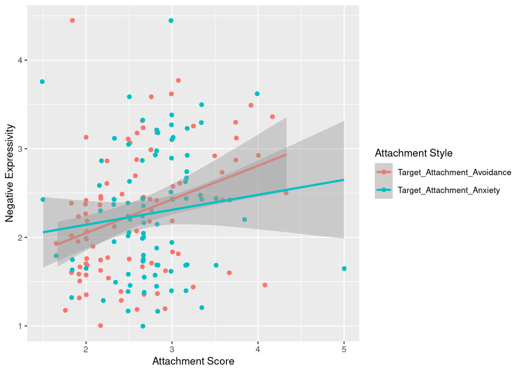

```r
#Output the graph

plotp1
```

### Prediction 1 Results

Negative Emotion

Results indicated a positive direction in terms of the higher one scores in avoidant attachment the more they are willing to express their emotions for a negative event to their partner. Despite this being significant, this does not support the first part of the hypothesis.

Results indicated a positive direction in terms of the higher one scores in anxious attachment the more they are willing to express their emotions for a negative event to their partner. This was not significant. Regardless this did not support the directionality of the second part of the hypothesis.

### Prediction 2

```r
p2<-lm(positive_exp~Target_Attachment_Avoidance+Target_Attachment_Anxiety, data=labdata)

summary(p2)
```

```
##
## Call:
## lm(formula = positive_exp ~ Target_Attachment_Avoidance + Target_Attachment_Anxiety,
##     data = labdata)
##
## Residuals:
##      Min       1Q   Median       3Q      Max
## -1.44637 -0.41142  0.01801  0.32155  1.61359
##
## Coefficients:
##                             Estimate Std. Error t value Pr(>|t|)
## (Intercept)                  3.07604    0.41161   7.473  6.8e-11 ***
## Target_Attachment_Avoidance -0.06777    0.10542  -0.643    0.522
## Target_Attachment_Anxiety    0.14487    0.12308   1.177    0.242
## ---
## Signif. codes:  0 '***' 0.001 '**' 0.01 '*' 0.05 '.' 0.1 ' ' 1
##
## Residual standard error: 0.6225 on 84 degrees of freedom
##   (10 observations deleted due to missingness)
## Multiple R-squared:  0.019,  Adjusted R-squared:  -0.004354
## F-statistic: 0.8136 on 2 and 84 DF,  p-value: 0.4467
```

```r
#Generate Graph
plotp2<-ggplot(data=labMelt,
              aes(x=Attachment_Score,
                  y=positive_exp,
                  color=Attachment_Style))+
  labs(x="Attachment Score",
       y="Positive Expressivity",
       color="Attachment Style")+
  geom_jitter()+
  geom_smooth(method="lm")+
  theme_gray(base_size=10)
  scale_color_discrete(labels=c("Avoidance","Anxiety"))
```

[output not shown]

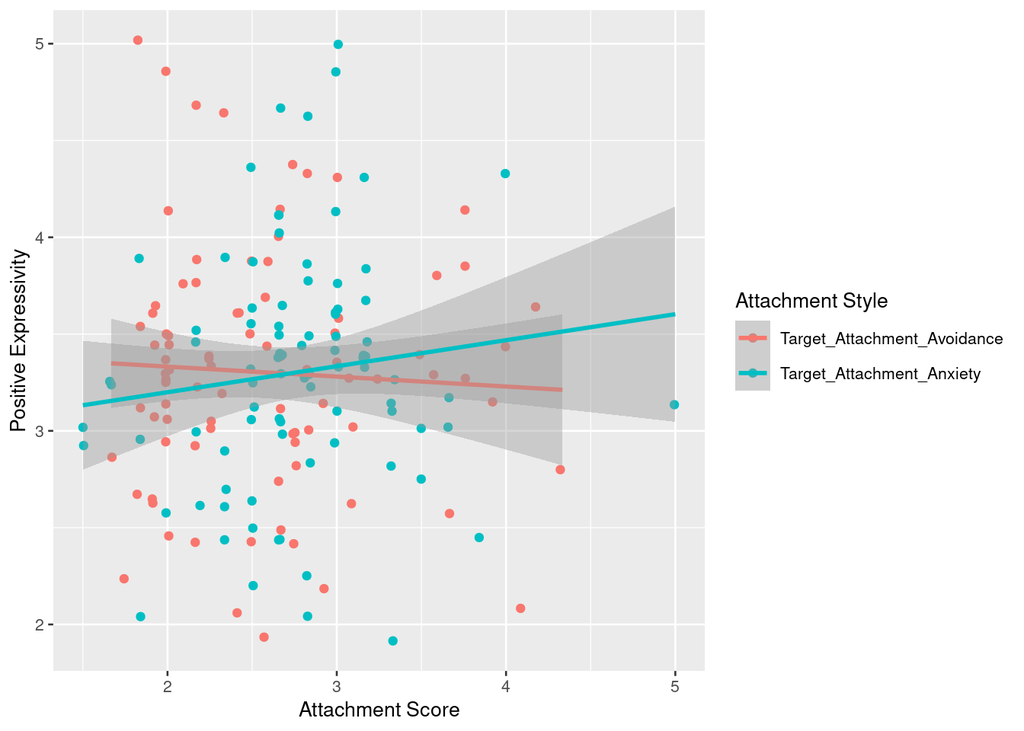

```r
  #The above or last line refers to the legend

#Output the graph

plotp2
```

### Prediction 2 Results

Results indicated a negative direction in terms of the higher one scores in avoidant attachment the less they are willing to express their emotions for a positive event to their partner. This is not significant and does not support the first part of the hypothesis.

Results indicated a positive direction in terms of the higher one scores in anxious attachment the more they are willing to express their emotions for a positive event to their partner. This was not significant. This does not support the second part of the hypothesis.